# Problem Set 5

Westley Cook

3/18/2020

##### Worked With: None

## Question 1: Mad Libs

**ML 1)** Not all respondents were asked every question. **2,652** respondents were asked the question about whether the USA should create a gun registry.

**ML 2)** Of the respondents that got asked all four gun policy questions, **24.53%** are gun owners.

**ML 3)** The average “agreement” score (from 1-4) on the statement_gun_rights variable is **2.17** for those respondents who live in households without guns, while the average “agreement” score in households with guns is **2.15**.

**ML 4)** Another set of questions asks about religion. The first ranked category of religion for the age group of people 18-30 is **“Nothing in particular.”** The first-ranked religion category for people 30 and older is **“Catholic.”**

**ML 5)** Lots of people say that the younger generation has the highest percent of “nones” (people who answer “nothing in particular”, when you ask them their religion). In the 18-30 age group, “nothing in particular” is ranked **1**, while in the 30 and above group, “nothing in particular” is ranked **4**.

**ML 6)** In the group of “nones,” the most popular position is to **“Strongly Agree”** that it is more important for the government to control who owns guns than it is for the government to protect the right to own guns.

## Question 2: Simulations with List Columns

#### 2a)

I wrote a function to sample the suit of n cards.

#### 2b)

I made a tibble that shows the result of drawing 2 cards 10 times.

#### 2c)

I added two columns (one for each card drawn) which say whether the card was red (hearts or diamonds) or not.

#### 2d)

I added a third new column, showing the color outcome of each draw, and produced the following table:

Drawing Two Cards

Card Colors

| Draw | First card red? | Second card red? | Color Outcome |
| --- | --- | --- | --- |
| clubs, hearts | FALSE | TRUE | Mixed |
| clubs, spades | FALSE | FALSE | Both black |
| diamonds, spades | TRUE | FALSE | Mixed |
| clubs, spades | FALSE | FALSE | Both black |
| diamonds, hearts | TRUE | TRUE | Both red |
| spades, clubs | FALSE | FALSE | Both black |
| clubs, hearts | FALSE | TRUE | Mixed |
| clubs, spades | FALSE | FALSE | Both black |
| spades, hearts | FALSE | TRUE | Mixed |
| clubs, hearts | FALSE | TRUE | Mixed |

#### 2e)

A simulation of drawing two cards 1000 times resulted in **48.90%** of draws having “mixed” colors.

## Question 3: Modeling a Study Population

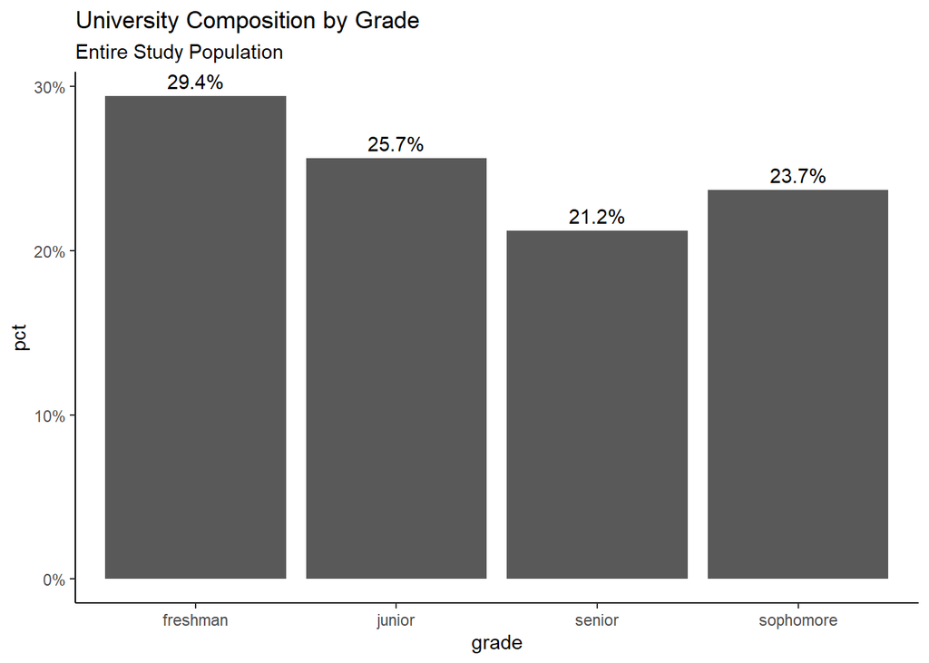

## Question 4: Sampling

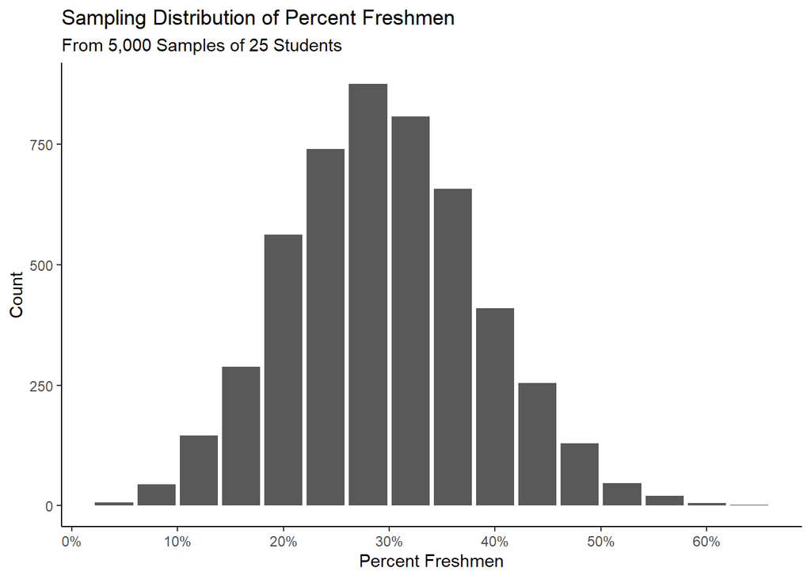

## Question 5: Sample Size

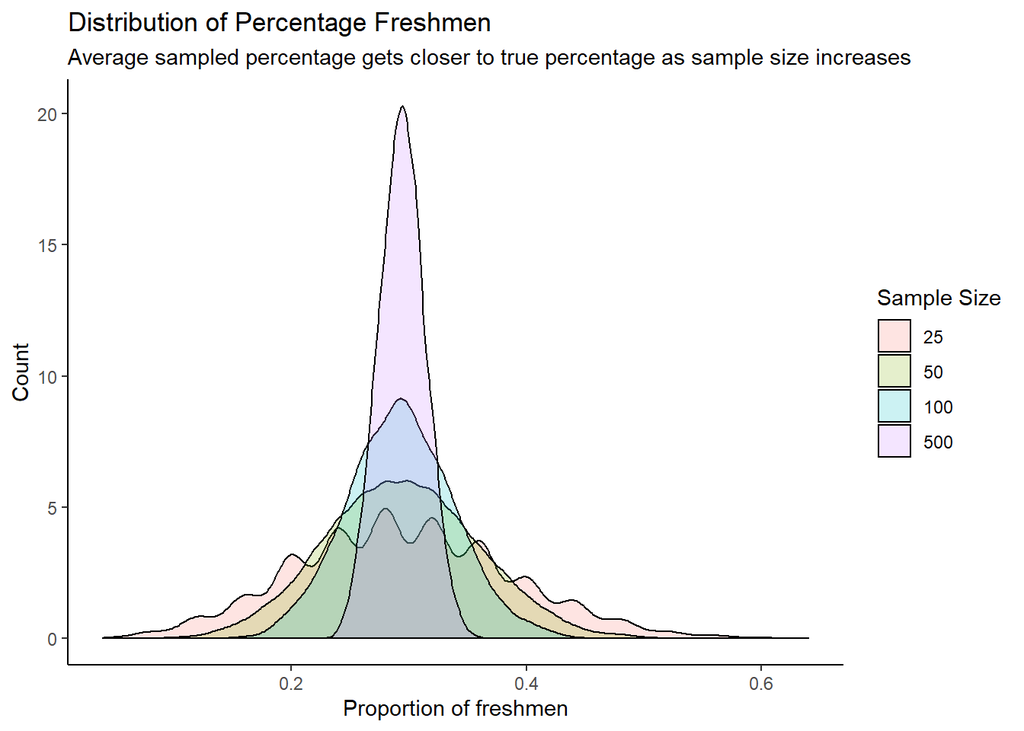

## Question 6: Publish the Plot

View my published plot at https://rpubs.com/wkcook/585752

## Question 7: Reprex

Find my reprex at https://github.com/GOV-1005-Spring-2020/problem-set-5-westleycook/issues/1

## Question 8: Understanding Sampling

Although my country has ten states, the population is extraordinarily dense; the five major cities are home to 70% of the total population. Because I only care about the popular vote, **I’ll spend the last of my polling budget running 5 polls of 1,000 randomly sampled people** (one in each major city).

The best way to obtain accurate information about the voting preferences of the **population** (every person in my country) would be a **census**, but unfortunately that isn’t possible; unlike Mike Bloomberg, I just don’t have that kind of money to spare. The next best way to get the info I want about the **population parameter** (the proportion of voters who will choose me) is through **sampling**. A larger sample size means less variability, which should translate to a more accurate **point estimate** than we would obtain with smaller samples. In other words, with a few large samples rather than more smaller samples, we can be more confident that the estimates we make from our samples are accurately describing the population. This is important! I want to know with confidence what matters to urban voters and where to focus my efforts to win their vote.

Furthermore, because 70% of the total population lives in the five major cities, our **random samples** across those cities can be assumed to be fairly **representative** and **generalizable** - that is, the sample’s characteristics should approximate the population’s characteristics, meaning the sample proportion of people who will vote for me should be close to the actual population proportion of people who will vote for me. Of course, by focusing exclusively on the urban areas in these polls, we’re ignoring the 30% of the country that live elsewhere, and our results may not be generalizable to them; our sample is **biased** toward urban voters. But prior polls have estimated that in rural areas I have a double-digit lead over my rivals, so I’m not too concerned about that.